# When Protest Enters Public Space

The Effects of Direct Exposure on Bystanders

with Tim Wappenhans, Ferdinand Geißler, Felix Hartmann, Daniel Bischof, Johannes Giesecke, Heike Klüver, Macartan Humphreys, and Lukas F. Stoetzer  
Violeta HaasAssistant Professor in Political Science  
Trinity College Dublin

## Typical Perspective

[figure not shown]

> “the spectators are an integral part of the situation, for, as likely as not, the audience determines the outcome of the fight.”

Schattschneider 1960

## Bystander Perspective

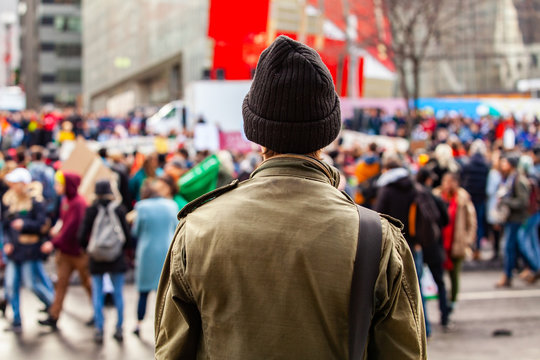

## Protest affects political outcomes

**Protest events move:**

- Public opinion (Mazumder 2018; Wasow 2020; Reny & Newman 2021)
- Voting (Madestam et al. 2013; Ellinas & Lamprianou 2024; Fabel et al. 2025; Valentim 2023)
- Media agendas and elite communication (Wasow 2020; Barrie, Fleming & Rowan 2024)
- Policy and legislative behavior (McAdam & Su 2002; Soule & Olzak 2004; Biggs & Andrews 2015; Enos et al. 2019)

## Protest Effects as Bundles

**But the observed effect can arrive through several channels:**

1. Encountering protesters in the street
2. Media coverage and elite discourse (Wasow 2020; Fabel et al. 2025)
3. Diffusion through social networks (Fabel et al. 2025)
4. Later movement activity (Madestam et al. 2013)

→ Observational designs mix encounters with everything protests set in motion.

## Participants and mediated exposure

**Studies isolating effects more cleanly tend to do one of two things:**

- Focus on a different actor altogether: participants (Cantoni et al. 2019; Bursztyn et al. 2021)
- Use mediated exposure: images, videos, or vignettes (Feinberg, Willer & Kovacheff 2020; Manekin & Mitts 2022; Shuman et al. 2021, 2024)

We know considerably more about how citizens respond to *representations* of collective action than about what happens when collective action enters their immediate physical and social space.

→ Multisensory cues produce strong affective responses (Schirmer & Adolphs 2017)

## The ideal design

Held fixed

Same political and  
media environment

Similar citizens

Randomize the encounter

Control  
no protest encounter

vs

Treatment  
*incidental* protest encounter

Measure

Immediate effects

Longer-term (mediated) effects

→ A preregistered field experiment that randomizes the encounter itself.

## Case: Friday’s for Future

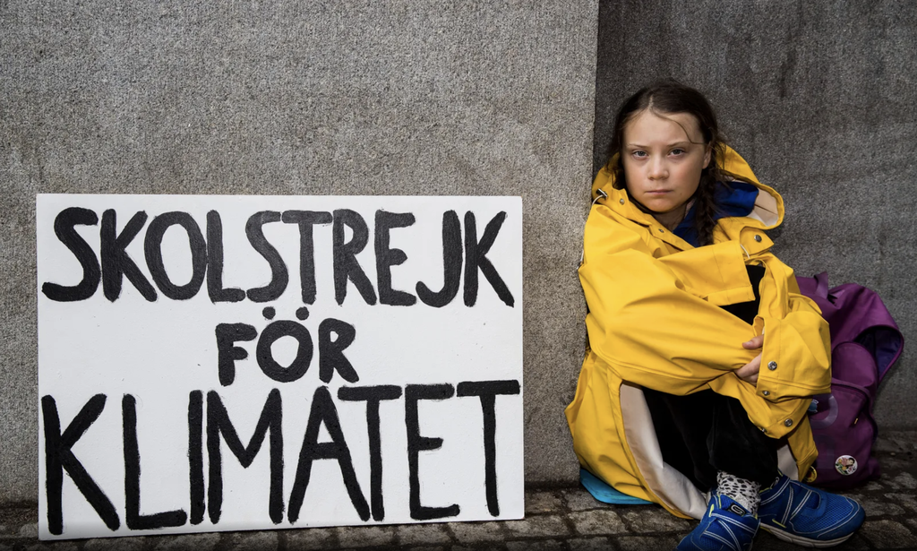

Youth-led climate movement since 2018; recurring strikes; large, peaceful, highly visible

## Experimental Setup

- Three-wave field experiment (N = 262; September ’23 + March ’24 + September ’24)
- Pre-, Post- and Follow-up surveys
- Screening: unexposed, not planning to join, at least 16, fluent in German
- 50€ Compensation + 10€ for follow-up
- Cover task: count park benches, for a supposed study of street accessibility
- Placebo items on environment, immigration, and redistribution

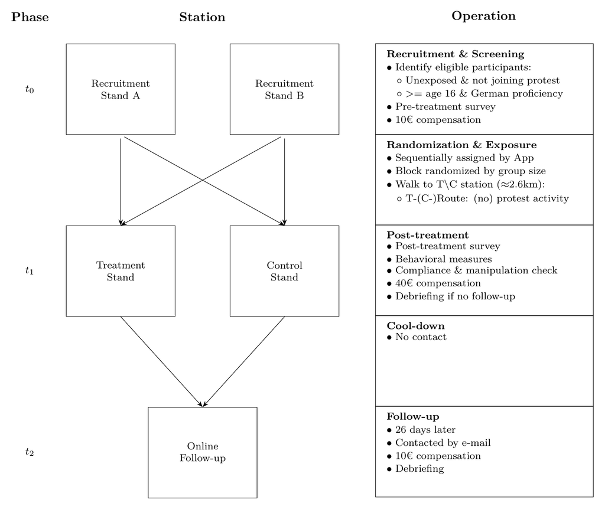

## Manipulating incidental encounters

[figure not shown]

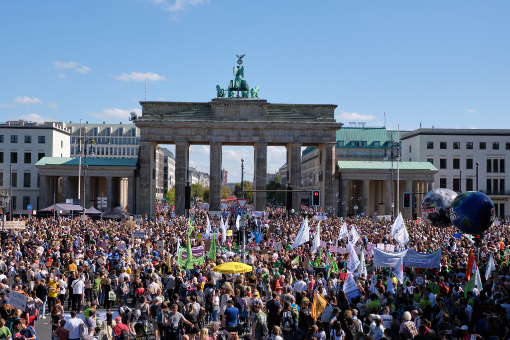

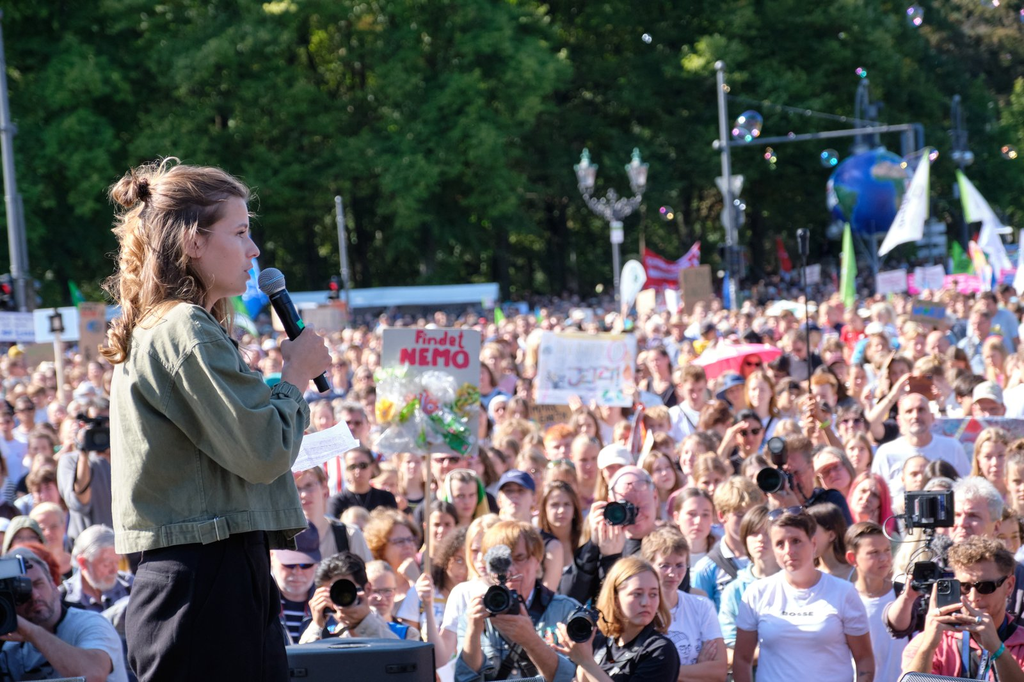

Route and Rally at the Brandenburg Gate showing salient sensory cues during W1 (15 September 2023)

Pedestrians were randomly assigned to walk one of two routes (≈ 2.6 km):

- treatment group observed and/or heard protest activity
- control group did not see or hear any protest activity

## Randomization App

People rarely walk the streets alone!

Sequential block randomization by group size (Moore and Moore 2017), assigned in real time.

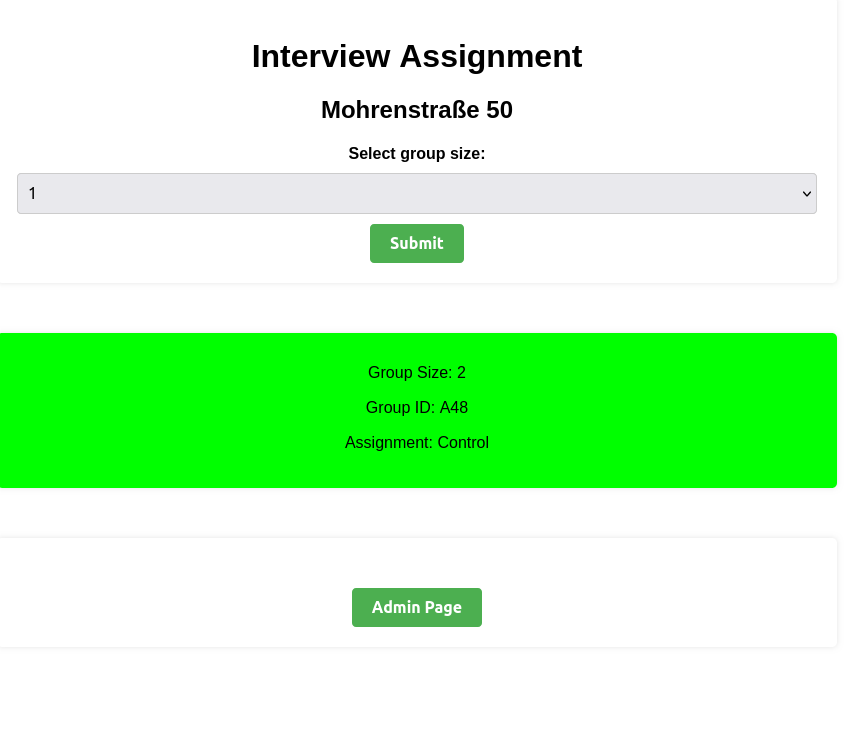

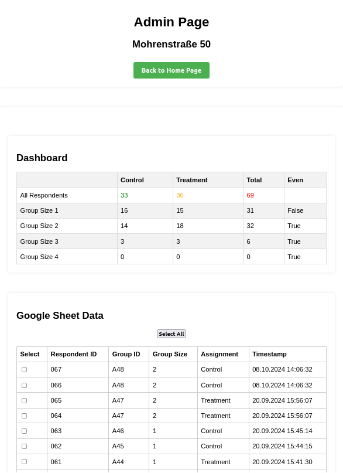

## Outcomes

Within-design

**Pre-, Post and Follow-up survey**

- Descriptive norms and injunctive norms
- Environmental attitudes
- Support for the Greens

Between-design

**Post survey, from the study compensation**

- A donation, in €10 steps
- A newsletter sign-up

## Local average treatment effect (LATE)

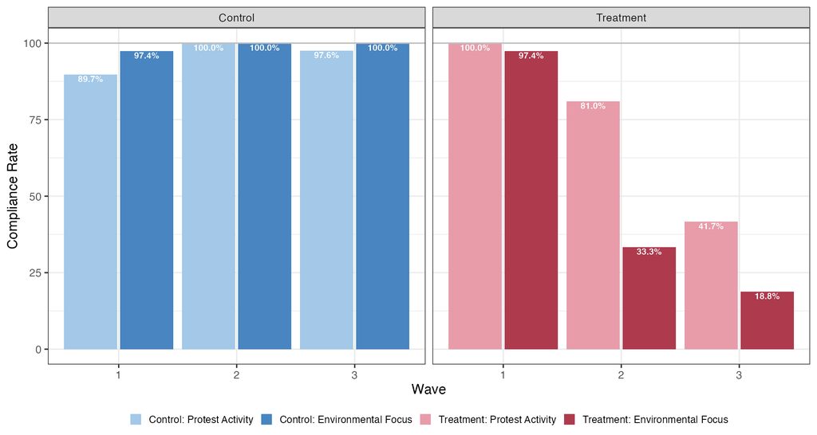

Since not every treated participant noticed the protest, we instrument self-reported exposure with randomized assignment (2SLS).

Within-design

$$Y_{t_1i}=\alpha+\beta\,\widehat{\text{Exposure}}_i+\gamma Y_{t_0i}+\varepsilon_i$$

Between-design

$$Y_{t_1i}=\alpha+\beta\,\widehat{\text{Exposure}}_i+\varepsilon_i$$

- Clustered SE by group ID
- Results for individual waves
- Precision-weighted average effect pooled across waves

## Main Results

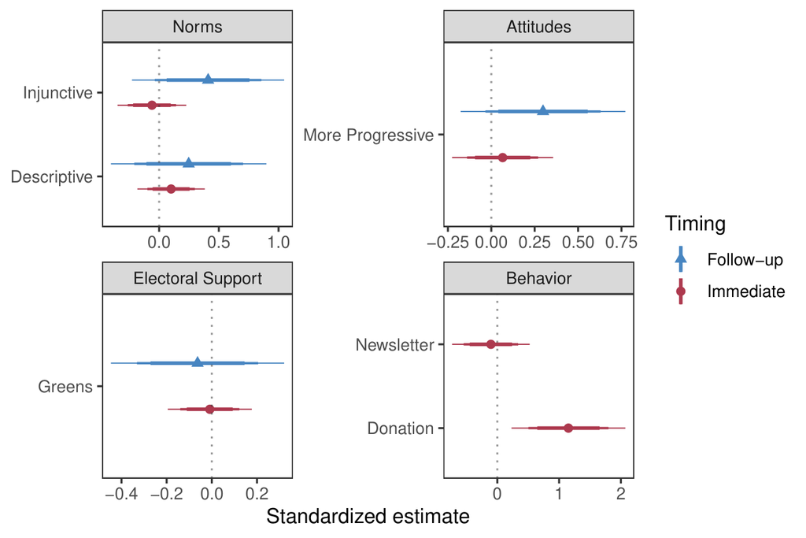

Norms, environmental attitudes, and Green support barely move in the immediate post-survey. **Bystanders give about €4.45 more** to the environmental cause.

## Heterogeneous effects

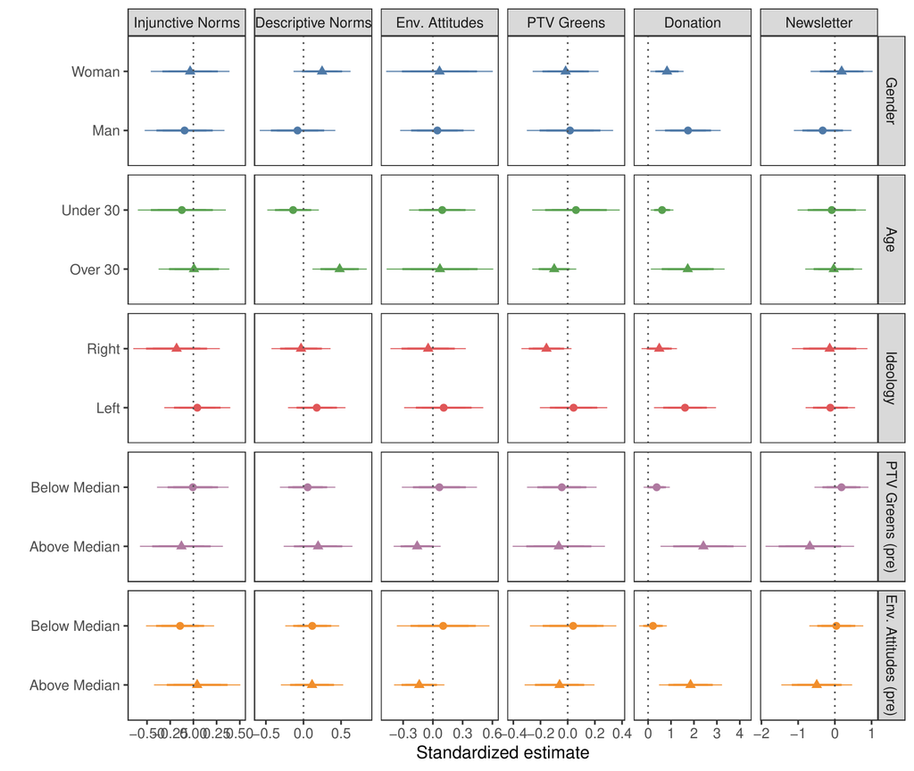

Attitudes stay mainly zero across groups. Donations are largest among people **already predisposed** toward environmental protection.

## Three implications

1. **Limited direct influence on bystanders.** Even large, peaceful, highly visible demonstrations leave attitudes, perceived norms, and electoral preferences largely unchanged.

→ Documented effects may depend less on encounters than on what protest sets in motion: repeated exposure, media amplification, interpersonal diffusion, and elite response (Wasow 2020; Madestam et al. 2013; Valentim 2023)

2. **How protest effects are identified empirically.** Observational designs based on occurrence, size, or timing measure a compound effect, often falsely attributed to encounter.

→ To understand how protest generates political change, we need to carefully distinguish different channels.

3. **Direct exposure is not entirely inconsequential.** Bystanders give greater material support to the cause, concentrated among those already sympathetic.

→ Conventional protest may be better able to activate existing sympathies than change established political views.

## Acknowledgments

[figure not shown]

**21 RAs on the ground full day for each wave. Thank you!**

Noah Badenhoop, Alma Below, Jana Krischke, Felix Heimburger, Eren Aytac, Madlen Beck, Antonia Briel, Nora Chirikure, Ahmed Elebrashi, William Fernandez, Maurice Baudet von Gersdorff, Janosch Glöckner, Inga Haudan, Annina Hermes, Philipp Heyna, Lukas Kern, Ruth Meissner, Teresa Hofmann Muñoz, Lennard Naumann, Cristian-Liviu Nicolescu, Anaïs Nimubona, Abigail Peña, Sophie Randerath, Magdalena Römischer, Alena Scheinert, Luca Schenk, Claudia Schliepe, Charlotte Schlüter, Johan Schlüter, Evelyn Schneider, Cole Simon, Jonathan Stahl, Marlene Steenken, Quentin Strelli, Frederik Thieme, Lara Türmer, and Lukas Wessling.

## Thank you!

violeta.haas@tcd.ie

# Appendix

Wave estimates →

### Design

SI Study Overview SI Materials SI Routes, 15 Sep 2023 SI Routes, 1 Mar 2024 SI Routes, 20 Sep 2024

### Sample and diagnostics

SI Did they see it? SI Covariate balance SI Compliance shares SI Who complies SI Pre-registered power SI Donation amounts

## Waves and intent-to-treat

← Design & diagnostics Placebos & robustness →

### Complier estimates, by wave

LATE Norms LATE Environmental attitudes LATE Green support LATE Newsletter and donations

### Intent-to-treat

ITT Estimation ITT Norms ITT Environmental attitudes ITT Green support ITT Newsletter and donations

## Placebos and robustness

← Waves & ITT

### Placebo issues

SI Norms SI Attitudes SI Other parties SI Newsletter sign-up SI Donations

### Robustness

SI Two-sided tests SI Covariate-adjusted SI Follow-up subset SI Random subsamples SI Issue salience SI Social desirability SI Heterogeneity

## Study Overview

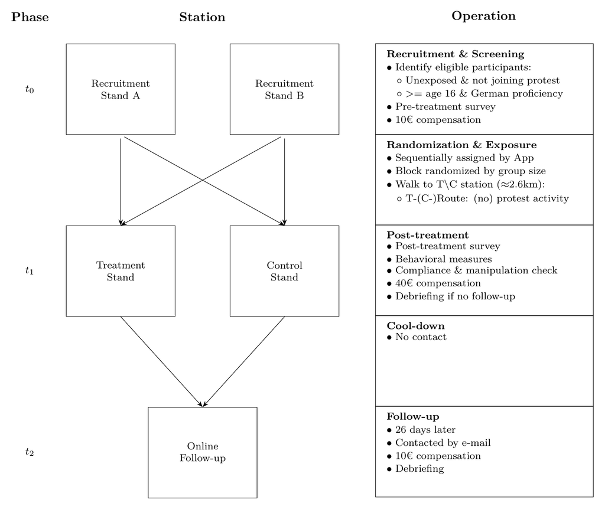

Two recruitment stands in waves 2 and 3. One stand in wave 1.

← Design & diagnostics

## Materials

[figure not shown]

Envelope with the pre-treatment survey, the route map, and a sealed post-treatment survey.

← Design & diagnostics

## Routes, 15 September 2023

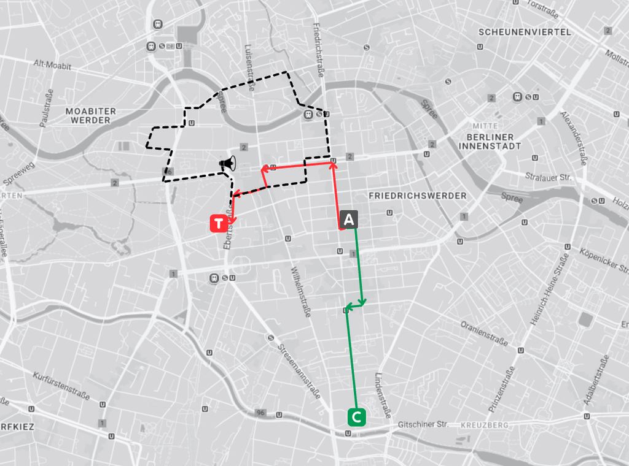

Global climate strike, about 24,000 participants.

← Design & diagnostics

## Routes, 1 March 2024

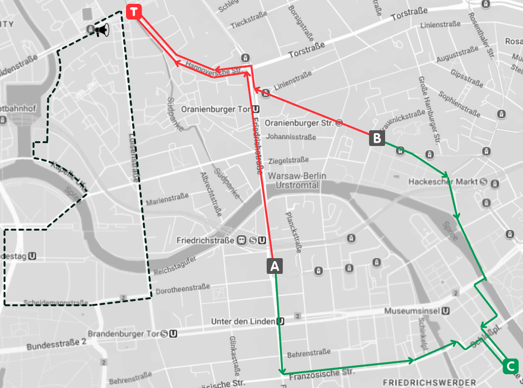

Co-organized with a union and an NGO, about 1,000 participants.

← Design & diagnostics

## Routes, 20 September 2024

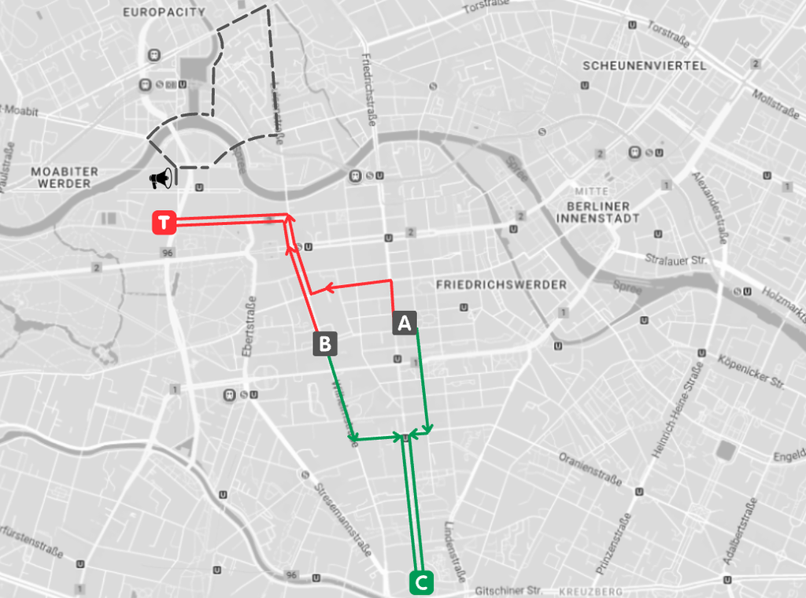

Global climate strike, about 5,000 participants.

← Design & diagnostics

## Did they see it?

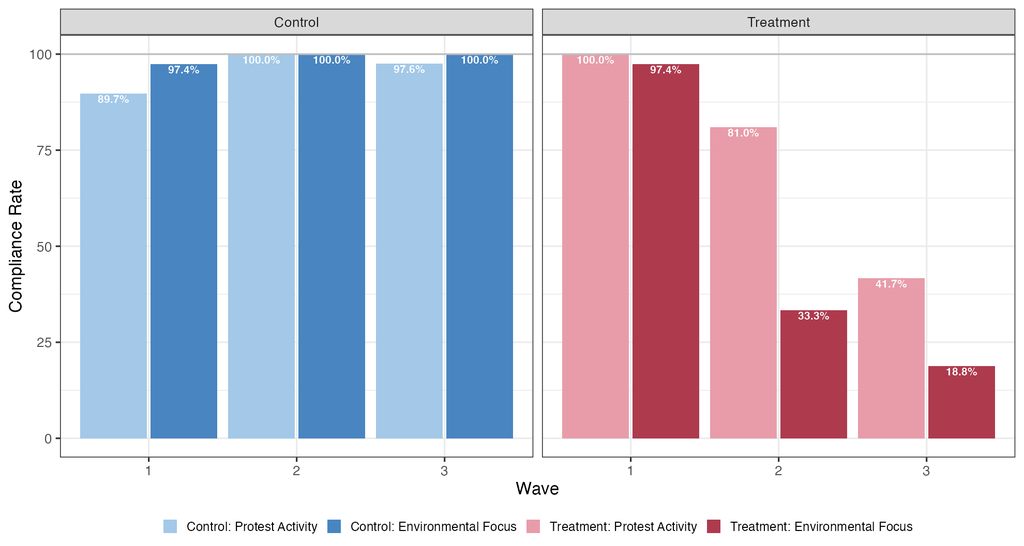

Control routes stay clear of the protest. On treatment routes, recognizing an **environmental** protest is nearly universal in wave 1 and uncommon later.

Light bars: saw a protest. Dark bars: recognized an environmental focus. Control is reverse-coded, so higher bars mean a successful manipulation in both arms.

← Design & diagnostics

## Covariate balance

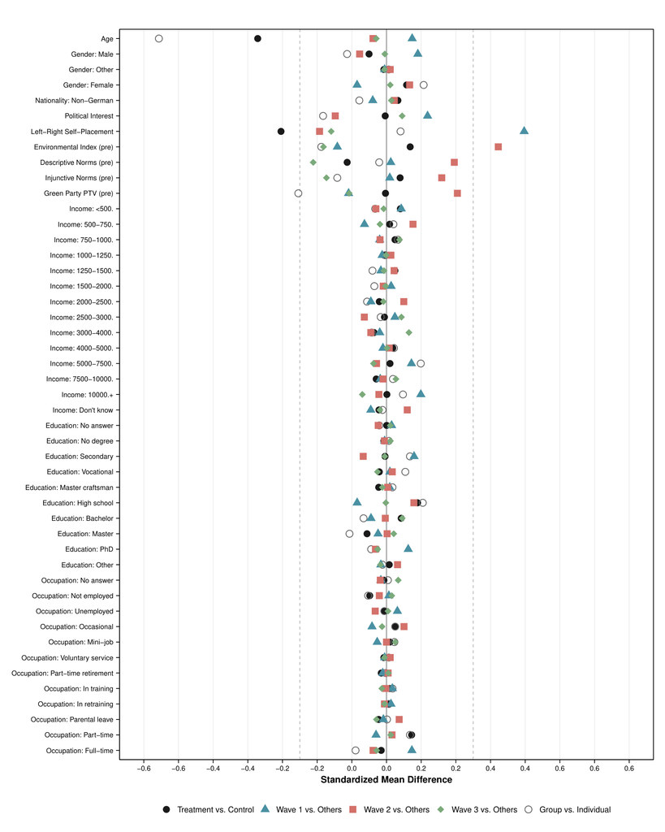

Pre-treatment covariates by route assignment.

← Design & diagnostics

## Compliance shares

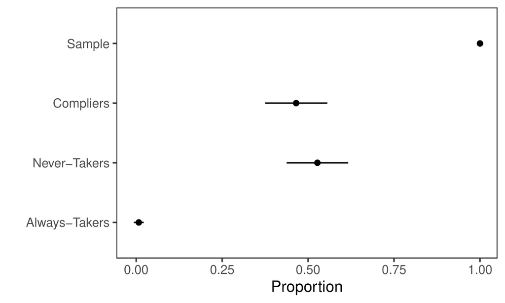

Compliers, never-takers, and always-takers.

← Design & diagnostics

## Who complies

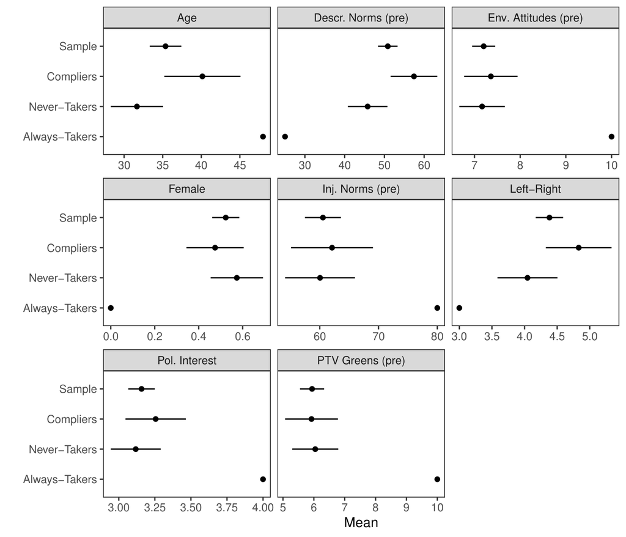

Pre-treatment covariates across compliance groups.

← Design & diagnostics

## Pre-registered power

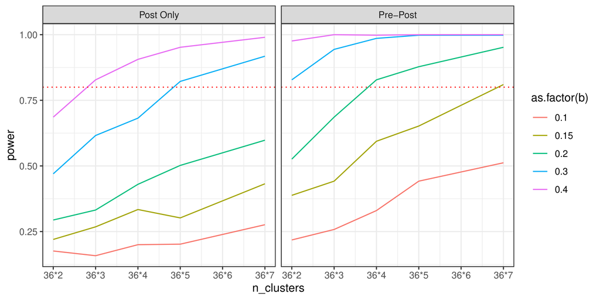

252 clusters were set for 80% power at a standardized effect of 0.15.

← Design & diagnostics

## Donation amounts

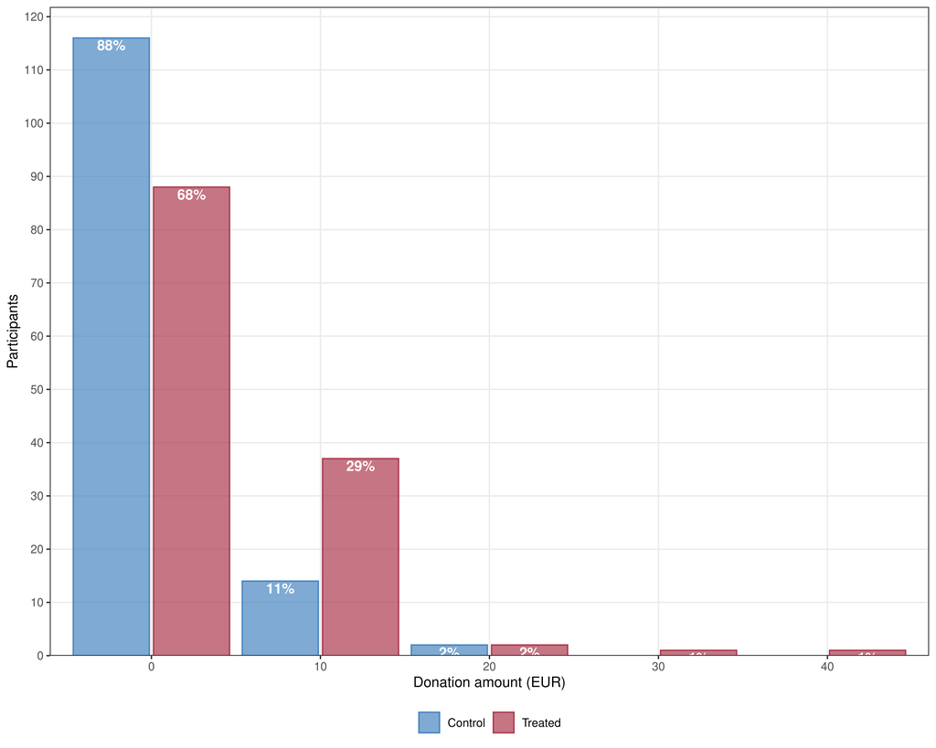

The increase is broad participation at low and moderate amounts.

← Design & diagnostics

## Norms by wave

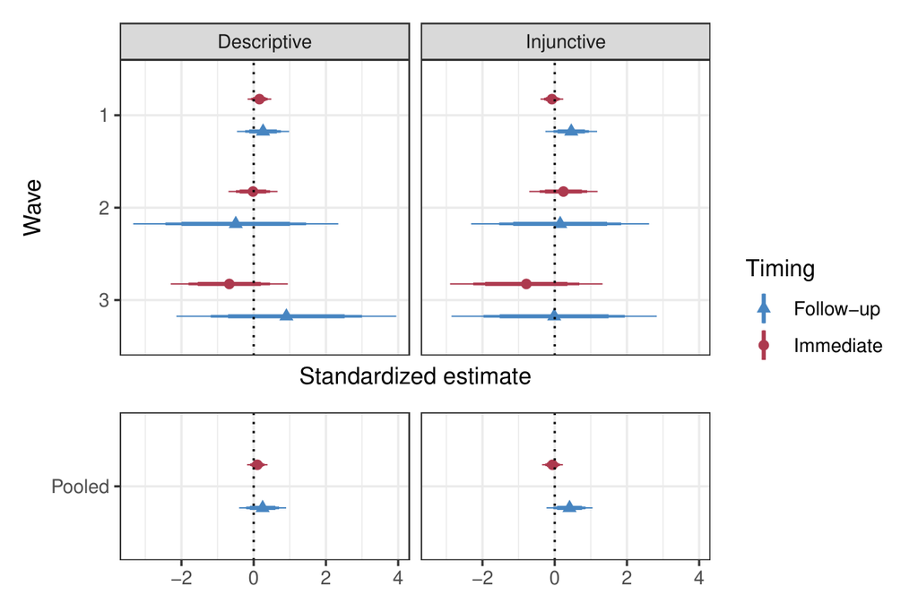

Wave-specific LATE for descriptive and injunctive norms.

← Waves & ITT

## Attitudes by wave

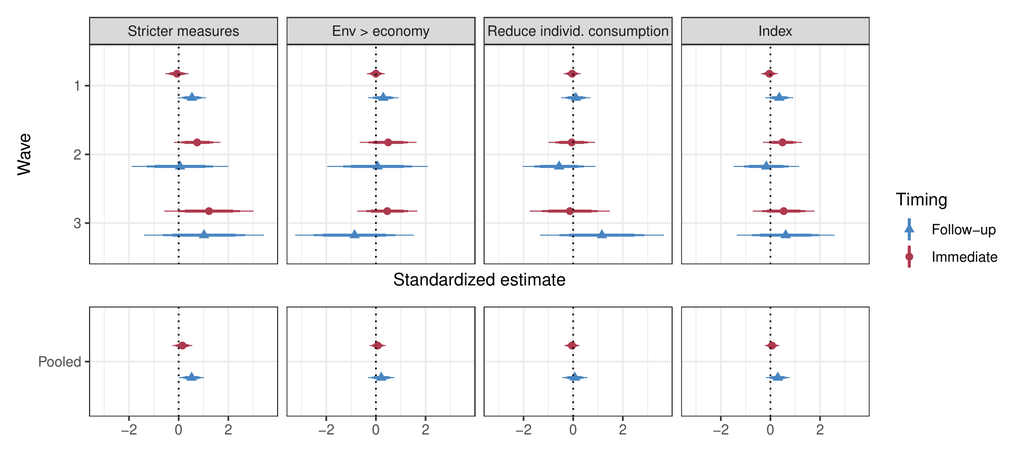

Wave-specific LATE for environmental attitudes.

← Waves & ITT

## Green support by wave

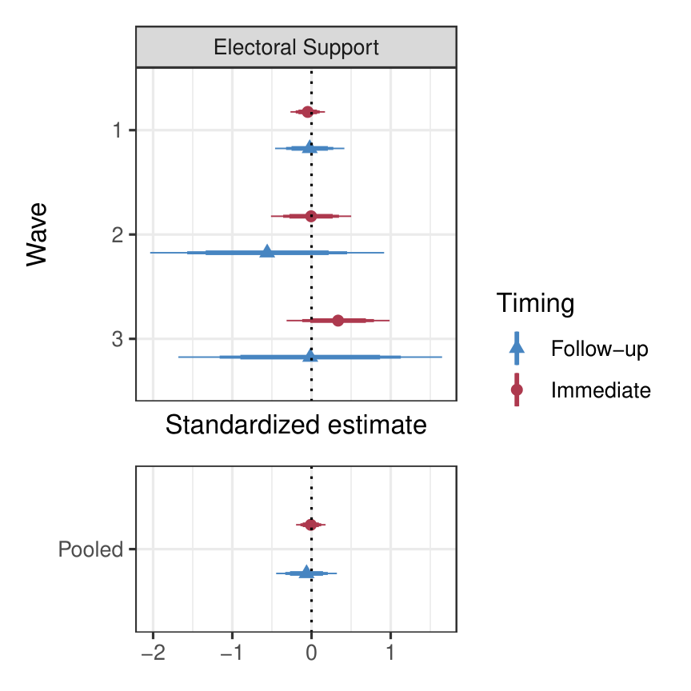

Wave-specific LATE for propensity to vote for the Greens.

← Waves & ITT

## Behavior by wave

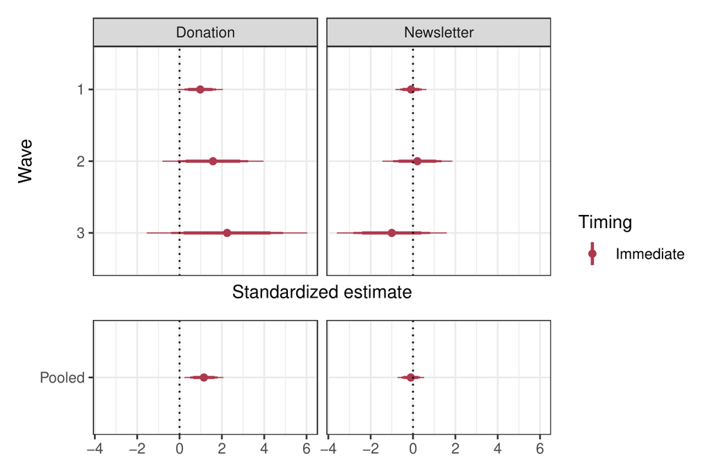

Wave-specific LATE for newsletter sign-up and donations.

← Waves & ITT

## Intent-to-treat (ITT)

Within-design

$$Y_{t_1i}=\alpha+\beta\,\text{Treatment}_i+\gamma Y_{t_0i}+\varepsilon_i$$

Between-design

$$Y_{t_1i}=\alpha+\beta\,\text{Treatment}_i+\varepsilon_i$$

- Clustered SE by group ID
- Results for individual waves
- Precision-weighted average effect pooled across waves

← Waves & ITT

## Norms, intent-to-treat

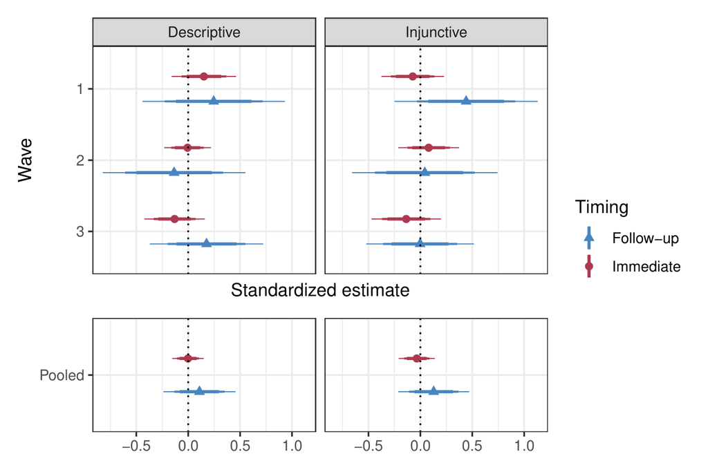

Effect of assignment to the treatment route, whether or not the respondent reported seeing the protest.

← Waves & ITT

## Attitudes, intent-to-treat

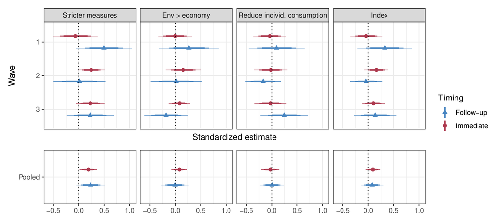

Intent-to-treat estimates for environmental attitudes.

← Waves & ITT

## Green support, intent-to-treat

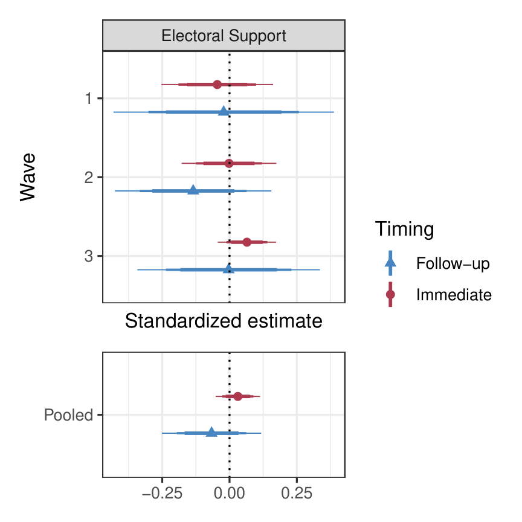

Intent-to-treat estimates for propensity to vote for the Greens.

← Waves & ITT

## Behavior, intent-to-treat

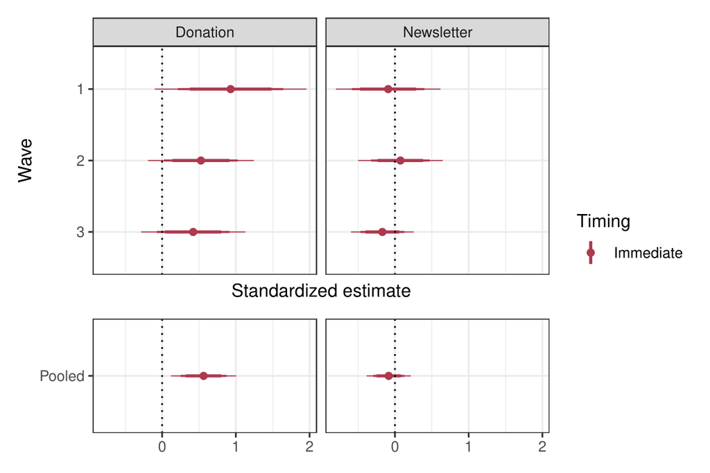

Intent-to-treat estimates for newsletter sign-up and donations.

← Waves & ITT